# 11. rTPC

Elliott Schmidt

2025-05-15

# Scenario

# Load packages

```r
library(tidyverse) # data manipulation
library(broom)
library(rTPC)
library(nls.multstart)
library(patchwork)
```

# Set working directory

```r
knitr::opts_knit$set(root.dir=working.dir)
```

# Import data

This data set has no point outliers however, in the next chunk 3 samples will be discarded due to poor data quailty

```r
lat_resp_dat <- read_delim("C:/Users/jc527762/OneDrive - James Cook University/PhD dissertation/Data/Chapter4_Latitude/import_files/lat_resp_dat_no_outliers.txt",
    delim = "\t", escape_double = FALSE,
    col_types = cols(area = col_skip(), rate.a.spec = col_skip()),
    trim_ws = TRUE)
```

# Data manipulation

```r
rows_of_data <- count(lat_resp_dat, sampleID)
lat_resp_dat2 <- lat_resp_dat |>
  mutate(dev.temp = as.factor(dev.temp),
         replicate = str_sub(sampleID, -1,-1),
         population = factor(population)) |>
                                           # number of observations = 5758
  filter(sampleID != "56.CARL.137.28,5.1", # 5777 - 76 = 5682
         sampleID != "56.CARL.137.28,5.2", # 5701 - 64 = 5618
         sampleID != "60.LCKM.152.30.1"  # 5637 - 76 = 5542
  ) |>
  filter(time_lag_sec >2001) |> # remove samples from first 5 cycles (i.e., first 33 minutes)
  group_by(sampleID) |>
  mutate(max_value_index = which.max(rate.output),
         row_number = row_number(),
         max.rate = max(rate.output),
         low.rate = mean(rate.output[order(rate.output)[1:10]]),
         net.rate = max.rate - low.rate) |>
  #filter(row_number <= max_value_index) |>
  ungroup() |>
  mutate(region = factor(region),
         dev.temp =factor(dev.temp),
         level = as.factor(case_when(tank >= 1 & tank <= 199 ~ 1,
                           tank >= 200 & tank <= 299 ~ 2,
                           tank >= 300 & tank <= 399 ~ 3,
                           TRUE ~ NA_real_)),
         female = factor(female)) |>
  unite("dev.temp.region",c(dev.temp,region), remove=FALSE) |>
  mutate(dev.temp.region = factor(dev.temp.region)) |>
  mutate(dev.temp.region =as.numeric(dev.temp.region))

lat_resp_dat2_extended <- lat_resp_dat2 |>
  group_by(sampleID) |>
  summarise(t =last(t)+0.1,
            rate.output =0,
            .groups ="drop") %>%
  bind_rows(lat_resp_dat2, .) |>
  arrange(sampleID, t)
```

# rTPC

**rTPC** is made to work across multiple data samples, however, we will first start by working with just one sample, fitting just one type of curve. The first curves that we are going to fit are called *sharpeschoolhigh_1981* and *gaussian_1987*.

## Sharpeschoolhigh_1981

```r
lat_resp_dat3 <- lat_resp_dat2 |> filter(sampleID =="101.LSBI.135.30.1")
start_vals <- get_start_vals(lat_resp_dat3$t, lat_resp_dat3$rate.output, model_name ='sharpeschoolhigh_1981')

mod <- nls.multstart::nls_multstart(rate.output~sharpeschoolhigh_1981(temp = t, r_tref, e, eh, th, tref = 35),
                                    data=lat_resp_dat3,
                                    iter=c(3,3,3,3),
                                    start_lower =start_vals - 1,
                                    start_upper =start_vals +1,
                                    lower =get_lower_lims(lat_resp_dat3$t, lat_resp_dat3$rate.output, model_name ='sharpeschoolhigh_1981'),
                                    upper =get_upper_lims(lat_resp_dat3$t, lat_resp_dat3$rate.output, model_name ='sharpeschoolhigh_1981'),
                                    supp_errors='Y',
                                    convergence_count =FALSE)

summary(mod)
```

```
##
## Formula: rate.output ~ sharpeschoolhigh_1981(temp = t, r_tref, e, eh,
##     th, tref = 35)
##
## Parameters:
##        Estimate Std. Error t value Pr(>|t|)
## r_tref 570.5664    66.5456   8.574 1.34e-10 ***
## e        1.6076     0.4547   3.536  0.00105 **
## eh      20.0000    18.2580   1.095  0.27989
## th      37.0530     0.3208 115.499  < 2e-16 ***
## ---
## Signif. codes:  0 '***' 0.001 '**' 0.01 '*' 0.05 '.' 0.1 ' ' 1
##
## Residual standard error: 172.8 on 40 degrees of freedom
##
## Number of iterations to convergence: 12
## Achieved convergence tolerance: 1.49e-08
```

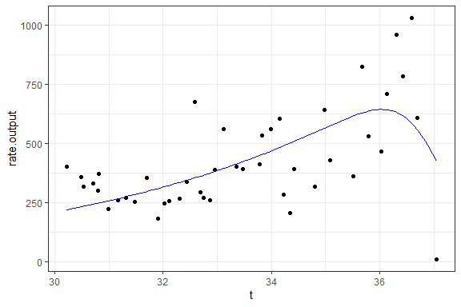

```r
preds <- data.frame(t =seq(min(lat_resp_dat3$t), max(lat_resp_dat3$t), length =100))
preds <- broom.mixed::augment(mod,newdata =preds)
x <- predict(mod, newdata =preds)
ggplot(preds) +
geom_point(aes(t, rate.output), lat_resp_dat3) +
geom_line(aes(t, .fitted), col = 'blue') +
theme_bw()
```

## Gaussian_1987

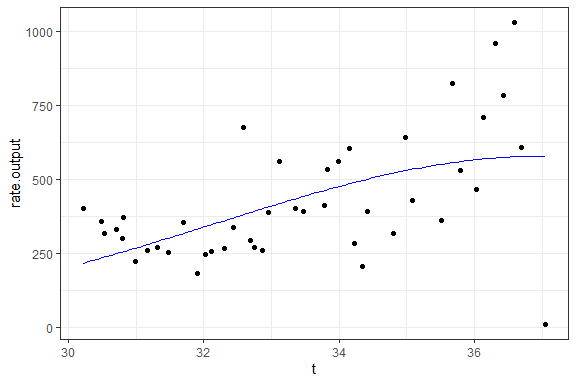

```r
start_vals <- get_start_vals(lat_resp_dat3$t, lat_resp_dat3$rate.output, model_name ='gaussian_1987')
mod <- nls.multstart::nls_multstart(rate.output~gaussian_1987(temp = t, rmax, topt, a),
                                    data=lat_resp_dat3,
                                    iter=c(3,3,3),
                                    start_lower =start_vals - 1,
                                    start_upper =start_vals +1,
                                    lower =get_lower_lims(lat_resp_dat3$t, lat_resp_dat3$rate.output, model_name ='gaussian_1987'),
                                    upper =get_upper_lims(lat_resp_dat3$t, lat_resp_dat3$rate.output, model_name ='gaussian_1987'),
                                    supp_errors='Y',
                                    convergence_count =FALSE)

preds <- data.frame(t =seq(min(lat_resp_dat3$t), max(lat_resp_dat3$t), length =100))
preds <- broom.mixed::augment(mod,newdata =preds)
x <- predict(mod, newdata =preds)
ggplot(preds) +
geom_point(aes(t, rate.output), lat_resp_dat3) +
geom_line(aes(t, .fitted), col = 'blue') +
theme_bw()
```

We can can now see both curves fit to the data we have and how they fit differently. To make comparisons of curves easier we can fit multiple curves onto the same plot. Let’s try some more curves and fit them onto the same plot.

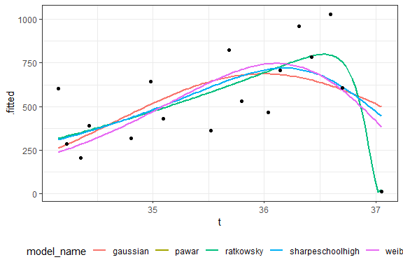

```r
lat_resp_dat3 <- lat_resp_dat2 |> filter(sampleID =="101.LSBI.135.30.1",
                                         t >34) |>
  select(sampleID, t, rate.output)

d_fits <- lat_resp_dat3 |>
  #group_by(sampleID) |>
  nest(data=c(t, rate.output)) |>
  mutate(
    gaussian =map(data, ~nls.multstart::nls_multstart(
      rate.output~gaussian_1987(temp = t, rmax, topt, a),
                                    data=.x,
                                    iter=c(3,3,3),
                                    start_lower =get_start_vals(lat_resp_dat3$t, lat_resp_dat3$rate.output, model_name ='gaussian_1987') - 1,
                                    start_upper =get_start_vals(lat_resp_dat3$t, lat_resp_dat3$rate.output, model_name ='gaussian_1987') +1,
                                    lower =get_lower_lims(.x$t, .x$rate.output, model_name ='gaussian_1987'),
                                    upper =get_upper_lims(.x$t, .x$rate.output, model_name ='gaussian_1987'),
                                    supp_errors='Y',
                                    convergence_count =FALSE)),
    sharpeschoolhigh =map(data, ~nls.multstart::nls_multstart(rate.output~sharpeschoolhigh_1981(temp = t, r_tref, e, eh, th, tref = 30),
                                    data=lat_resp_dat3,
                                    iter=c(3,3,3,3),
                                    start_lower =get_start_vals(lat_resp_dat3$t, lat_resp_dat3$rate.output, model_name ='sharpeschoolhigh_1981') - 1,
                                    start_upper =get_start_vals(lat_resp_dat3$t, lat_resp_dat3$rate.output, model_name ='sharpeschoolhigh_1981') +1,
                                    lower =get_lower_lims(lat_resp_dat3$t, lat_resp_dat3$rate.output, model_name ='sharpeschoolhigh_1981'),
                                    upper =get_upper_lims(lat_resp_dat3$t, lat_resp_dat3$rate.output, model_name ='sharpeschoolhigh_1981'),
                                    supp_errors='Y',
                                    convergence_count =FALSE)),
    weibull = map(data, ~nls_multstart(rate.output~weibull_1995(temp = t, a,topt,b,c),
                        data = lat_resp_dat3,
                        iter = c(4,4,4,4),
                        start_lower = get_start_vals(lat_resp_dat3$t, lat_resp_dat3$rate.output, model_name = 'weibull_1995') - 1,
                        start_upper = get_start_vals(lat_resp_dat3$t, lat_resp_dat3$rate.output, model_name = 'weibull_1995') + 1,
                        lower = get_lower_lims(lat_resp_dat3$t, lat_resp_dat3$rate.output, model_name = 'weibull_1995'),
                        upper = get_upper_lims(lat_resp_dat3$t, lat_resp_dat3$rate.output, model_name = 'weibull_1995'),
                        supp_errors = 'Y',
                        convergence_count = FALSE)),
    pawar = map(data, ~nls_multstart(rate.output~pawar_2018(temp = t, r_tref, e, eh, topt, tref = 15),
                        data = lat_resp_dat3,
                        iter = c(4,4,4,4),
                        start_lower = get_start_vals(lat_resp_dat3$t, lat_resp_dat3$rate.output, model_name = 'pawar_2018') - 10,
                        start_upper = get_start_vals(lat_resp_dat3$t, lat_resp_dat3$rate.output, model_name = 'pawar_2018') + 10,
                        lower = get_lower_lims(lat_resp_dat3$t, lat_resp_dat3$rate.output, model_name = 'pawar_2018'),
                        upper = get_upper_lims(lat_resp_dat3$t, lat_resp_dat3$rate.output, model_name = 'pawar_2018'),
                        supp_errors = 'Y',
                        convergence_count = FALSE)),
    ratkowsky = map(data, ~nls_multstart(rate.output~ratkowsky_1983(temp = t, tmin, tmax, a, b),
                        data = lat_resp_dat3,
                        iter = c(4,4,4,4),
                        start_lower = get_start_vals(lat_resp_dat3$t, lat_resp_dat3$rate.output, model_name = 'ratkowsky_1983') - 10,
                        start_upper = get_start_vals(lat_resp_dat3$t, lat_resp_dat3$rate.output, model_name = 'ratkowsky_1983') + 10,
                        lower = get_lower_lims(lat_resp_dat3$t, lat_resp_dat3$rate.output, model_name = 'ratkowsky_1983'),
                        upper = get_upper_lims(lat_resp_dat3$t, lat_resp_dat3$rate.output, model_name = 'ratkowsky_1983'),
                        supp_errors = 'Y',
                        convergence_count = FALSE)),
    johnson_lewin = map(data, ~suppressWarnings(nls_multstart(rate.output~ johnsonlewin_1946(temp = t, r0, e, eh, topt),
                        data = lat_resp_dat3,
                        iter = c(4,4,4,4),
                        start_lower = get_start_vals(lat_resp_dat3$t, lat_resp_dat3$rate.output, model_name = 'johnsonlewin_1946') - 1,
                        start_upper = get_start_vals(lat_resp_dat3$t, lat_resp_dat3$rate.output, model_name = 'johnsonlewin_1946') + 1,
                        lower = get_lower_lims(lat_resp_dat3$t, lat_resp_dat3$rate.output, model_name = 'johnsonlewin_1946'),
                        upper = get_upper_lims(lat_resp_dat3$t, lat_resp_dat3$rate.output, model_name = 'johnsonlewin_1946'),
                        supp_errors = 'Y',
                        convergence_count = FALSE))))

d_stack <- select(d_fits, -data) %>%
  pivot_longer(.,names_to = 'model_name', values_to ='fit', gaussian:ratkowsky)

newdata <- tibble(t =seq(min(lat_resp_dat3$t), max(lat_resp_dat3$t), length.out =100))
d_preds <- d_stack %>%
  mutate(., preds =map(fit, augment, newdata =newdata)) |>
  select(-fit) |>
  unnest(preds)

partial_data <- ggplot(d_preds, aes(t, .fitted)) +
  geom_line(aes(col =model_name), linewidth =1) +
  geom_point(aes(t, rate.output),
             data =lat_resp_dat3) +
  theme_bw() +
  theme(legend.position = "bottom"); partial_data
```

```r
lat_resp_dat3 <- lat_resp_dat2 |> filter(sampleID =="101.LSBI.135.30.1") |>
  select(sampleID, t, rate.output)

d_fits <- lat_resp_dat3 |>
  #group_by(sampleID) |>
  nest(data=c(t, rate.output)) |>
  mutate(
    gaussian =map(data, ~nls.multstart::nls_multstart(
      rate.output~gaussian_1987(temp = t, rmax, topt, a),
                                    data=.x,
                                    iter=c(3,3,3),
                                    start_lower =get_start_vals(lat_resp_dat3$t, lat_resp_dat3$rate.output, model_name ='gaussian_1987') - 1,
                                    start_upper =get_start_vals(lat_resp_dat3$t, lat_resp_dat3$rate.output, model_name ='gaussian_1987') +1,
                                    lower =get_lower_lims(.x$t, .x$rate.output, model_name ='gaussian_1987'),
                                    upper =get_upper_lims(.x$t, .x$rate.output, model_name ='gaussian_1987'),
                                    supp_errors='Y',
                                    convergence_count =FALSE)),
    sharpeschoolhigh =map(data, ~nls.multstart::nls_multstart(rate.output~sharpeschoolhigh_1981(temp = t, r_tref, e, eh, th, tref = 30),
                                    data=lat_resp_dat3,
                                    iter=c(3,3,3,3),
                                    start_lower =get_start_vals(lat_resp_dat3$t, lat_resp_dat3$rate.output, model_name ='sharpeschoolhigh_1981') - 1,
                                    start_upper =get_start_vals(lat_resp_dat3$t, lat_resp_dat3$rate.output, model_name ='sharpeschoolhigh_1981') +1,
                                    lower =get_lower_lims(lat_resp_dat3$t, lat_resp_dat3$rate.output, model_name ='sharpeschoolhigh_1981'),
                                    upper =get_upper_lims(lat_resp_dat3$t, lat_resp_dat3$rate.output, model_name ='sharpeschoolhigh_1981'),
                                    supp_errors='Y',
                                    convergence_count =FALSE)),
    weibull = map(data, ~nls_multstart(rate.output~weibull_1995(temp = t, a,topt,b,c),
                        data = lat_resp_dat3,
                        iter = c(4,4,4,4),
                        start_lower = get_start_vals(lat_resp_dat3$t, lat_resp_dat3$rate.output, model_name = 'weibull_1995') - 1,
                        start_upper = get_start_vals(lat_resp_dat3$t, lat_resp_dat3$rate.output, model_name = 'weibull_1995') + 1,
                        lower = get_lower_lims(lat_resp_dat3$t, lat_resp_dat3$rate.output, model_name = 'weibull_1995'),
                        upper = get_upper_lims(lat_resp_dat3$t, lat_resp_dat3$rate.output, model_name = 'weibull_1995'),
                        supp_errors = 'Y',
                        convergence_count = FALSE)),
    pawar = map(data, ~nls_multstart(rate.output~pawar_2018(temp = t, r_tref, e, eh, topt, tref = 15),
                        data = lat_resp_dat3,
                        iter = c(4,4,4,4),
                        start_lower = get_start_vals(lat_resp_dat3$t, lat_resp_dat3$rate.output, model_name = 'pawar_2018') - 10,
                        start_upper = get_start_vals(lat_resp_dat3$t, lat_resp_dat3$rate.output, model_name = 'pawar_2018') + 10,
                        lower = get_lower_lims(lat_resp_dat3$t, lat_resp_dat3$rate.output, model_name = 'pawar_2018'),
                        upper = get_upper_lims(lat_resp_dat3$t, lat_resp_dat3$rate.output, model_name = 'pawar_2018'),
                        supp_errors = 'Y',
                        convergence_count = FALSE)),
    ratkowsky = map(data, ~nls_multstart(rate.output~ratkowsky_1983(temp = t, tmin, tmax, a, b),
                        data = lat_resp_dat3,
                        iter = c(4,4,4,4),
                        start_lower = get_start_vals(lat_resp_dat3$t, lat_resp_dat3$rate.output, model_name = 'ratkowsky_1983') - 10,
                        start_upper = get_start_vals(lat_resp_dat3$t, lat_resp_dat3$rate.output, model_name = 'ratkowsky_1983') + 10,
                        lower = get_lower_lims(lat_resp_dat3$t, lat_resp_dat3$rate.output, model_name = 'ratkowsky_1983'),
                        upper = get_upper_lims(lat_resp_dat3$t, lat_resp_dat3$rate.output, model_name = 'ratkowsky_1983'),
                        supp_errors = 'Y',
                        convergence_count = FALSE)),
    johnson_lewin = map(data, ~suppressWarnings(nls_multstart(rate.output~ johnsonlewin_1946(temp = t, r0, e, eh, topt),
                        data = lat_resp_dat3,
                        iter = c(4,4,4,4),
                        start_lower = get_start_vals(lat_resp_dat3$t, lat_resp_dat3$rate.output, model_name = 'johnsonlewin_1946') - 1,
                        start_upper = get_start_vals(lat_resp_dat3$t, lat_resp_dat3$rate.output, model_name = 'johnsonlewin_1946') + 1,
                        lower = get_lower_lims(lat_resp_dat3$t, lat_resp_dat3$rate.output, model_name = 'johnsonlewin_1946'),
                        upper = get_upper_lims(lat_resp_dat3$t, lat_resp_dat3$rate.output, model_name = 'johnsonlewin_1946'),
                        supp_errors = 'Y',
                        convergence_count = FALSE))))

d_stack <- select(d_fits, -data) %>%
  pivot_longer(.,names_to = 'model_name', values_to ='fit', gaussian:ratkowsky)

newdata <- tibble(t =seq(min(lat_resp_dat3$t), max(lat_resp_dat3$t), length.out =100))
d_preds <- d_stack %>%
  mutate(., preds =map(fit, augment, newdata =newdata)) |>
  select(-fit) |>
  unnest(preds)

all_data <- ggplot(d_preds, aes(t, .fitted)) +
  geom_line(aes(col =model_name), linewidth =1) +
  geom_point(aes(t, rate.output),
             data =lat_resp_dat3) +
  theme_bw() +
  theme(legend.position = "bottom")
```

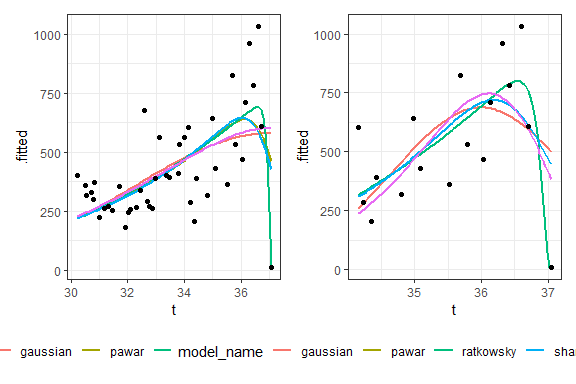

```r
p = all_data + partial_data
p
```

```r
#ggsave("figures/rTPC_fitting_multiple_models.pdf", dpi =300, width =6, height=5, units ="in")
```

In the plots above it looks like the *ratkowsky_1983* model fits the best. A typical ratkowsky fit is shown below.

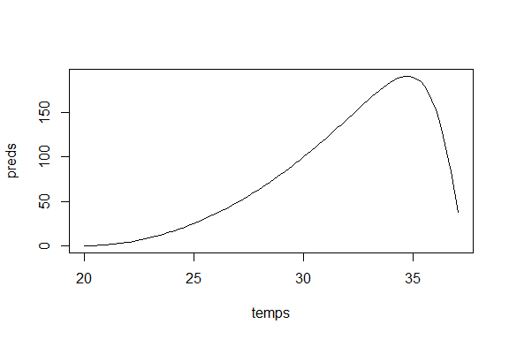

```r
temps <- seq(20, max(lat_resp_dat3$t), length.out = 100)
preds <- ratkowsky_1983(temp = temps, tmin = 20, tmax = 37.5, a = 1, b =1); plot(temps, preds, type = "l")
```

Let’s fit the *ratkowsky_1983* model to some of our sample data.

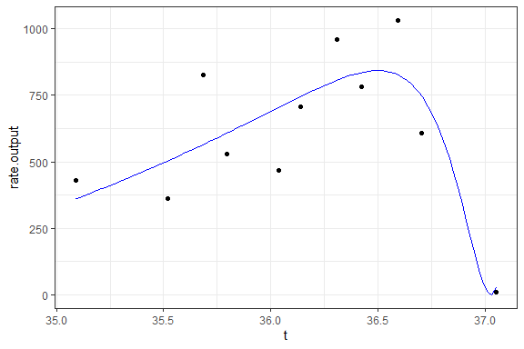

```r
lat_resp_dat3 <- lat_resp_dat2 |> filter(sampleID =="101.LSBI.135.30.1", t >35) |>
  select(sampleID, t, rate.output)
mod <- nls.multstart::nls_multstart(rate.output~ratkowsky_1983(temp = t, tmin, tmax, a, b),
                        data = lat_resp_dat3,
                        iter = c(5,5,5,5),
                        start_lower = get_start_vals(lat_resp_dat3$t, lat_resp_dat3$rate.output, model_name = 'ratkowsky_1983') - c(1,0,0,-0.9),
                        start_upper = get_start_vals(lat_resp_dat3$t, lat_resp_dat3$rate.output, model_name = 'ratkowsky_1983') + 1,
                        lower = get_lower_lims(lat_resp_dat3$t, lat_resp_dat3$rate.output, model_name = 'ratkowsky_1983'),
                        upper = get_upper_lims(lat_resp_dat3$t, lat_resp_dat3$rate.output, model_name = 'ratkowsky_1983'),
                        supp_errors = 'Y',
                        convergence_count = FALSE)

preds <- data.frame(t =seq(min(lat_resp_dat3$t), max(lat_resp_dat3$t), length =100))
preds <- broom.mixed::augment(mod,newdata =preds)
x <- predict(mod, newdata =preds)

ggplot(preds) +
geom_point(aes(t, rate.output), lat_resp_dat3) +
geom_line(aes(t, .fitted), col = 'blue') +
theme_bw()
```

Looks pretty good! Let’s try to fit the *ratkowsky_1983* to all of our samples now.

```r
lat_resp_dat4 <- lat_resp_dat2_extended |>
  filter(t >32) |>
  select(sampleID, t, rate.output)

d_fits <- lat_resp_dat4 |>
  #group_by(sampleID) |>
  nest(data=c(t, rate.output)) |>
  mutate(ratkowsky = map(data, ~nls_multstart(rate.output~ratkowsky_1983(temp = t, tmin, tmax, a, b),
                        data = .x,
                        iter = c(3,3,3,3),
                        start_lower = get_start_vals(.x$t, .x$rate.output, model_name = 'ratkowsky_1983') - 1,
                        start_upper = get_start_vals(.x$t, .x$rate.output, model_name = 'ratkowsky_1983') + 1,
                        lower = get_lower_lims(.x$t, .x$rate.output, model_name = 'ratkowsky_1983'),
                        upper = get_upper_lims(.x$t, .x$rate.output, model_name = 'ratkowsky_1983'),
                        supp_errors = 'Y',
                        convergence_count = FALSE)))

d_preds <- mutate(d_fits, new_data =map(data, ~tibble(t =seq(min(lat_resp_dat4$t), max(lat_resp_dat4$t), length =100)))) |>
  select(-data) |>
  pivot_longer(names_to = 'model_name', values_to = 'fit', c(ratkowsky)) |>
  mutate(preds =map2(fit, new_data, ~augment(.x, newdata =.y))) |>
  select(sampleID, model_name, preds) |>
  unnest(preds)

glimpse(d_preds)
```

```
## Rows: 9,700
## Columns: 4
## $ sampleID   <chr> "101.LSBI.135.30.1", "101.LSBI.135.30.1", "101.LSBI.135.30.…
## $ model_name <chr> "ratkowsky", "ratkowsky", "ratkowsky", "ratkowsky", "ratkow…
## $ t          <dbl> 32.00200, 32.06151, 32.12101, 32.18052, 32.24002, 32.29953,…
## $ .fitted    <dbl> 271.1385, 275.7996, 280.5004, 285.2410, 290.0212, 294.8412,…
```

[figure not shown]

```r
d_preds_trimmed <- d_preds |>
  group_by(sampleID, model_name) |>
  mutate(peak_index = which.min(.fitted)) |>
  mutate(row_number = row_number()) |>
  filter(row_number <= peak_index) |>
  select(-peak_index, -row_number) |>
  ungroup()

p <- ggplot(d_preds_trimmed) +
  geom_point(aes(t, rate.output), lat_resp_dat4) +
  geom_line(data =d_preds, aes(t, .fitted), col="salmon", linetype ="dashed", alpha=0.5) +
  geom_line(aes(t, .fitted, col ="red")) +
  facet_wrap(~sampleID, ncol =6) +
  theme_bw() + ylim(0,1500) +
  theme(legend.position ='none') +
  labs(x = 'Temperature (ºC)',
       y = 'Resting metabolilc rate',
       title = 'All fitted thermal performance curves')

p
```

Great job!

We can now extra different parameters for each one of our samples including estimates for trait max, CTmin, CTmax, Q10, thermal_safety_margins, thermal_tolerance, breadth, and skewness.

```r
d_params <- pivot_longer(d_fits, names_to ='model_name', values_to ='fit', c(ratkowsky)) |>
  mutate(params =map(fit, calc_params)) |>
  select(sampleID, model_name, params) |>
  unnest(params)
glimpse(d_params)
```

```
## Rows: 97
## Columns: 13
## $ sampleID              <chr> "101.LSBI.135.30.1", "101.LSBI.160.31,5.1", "101…
## $ model_name            <chr> "ratkowsky", "ratkowsky", "ratkowsky", "ratkowsk…
## $ rmax                  <dbl> 719.5251, 494.3077, 658.1178, 717.3004, 492.7948…
## $ topt                  <dbl> 36.511, 36.494, 36.435, 36.600, 36.535, 36.183, …
## $ ctmin                 <dbl> 27.503, 16.894, 24.961, 27.758, 23.569, 22.783, …
## $ ctmax                 <dbl> 37.089, 37.024, 36.912, 37.164, 37.023, 36.984, …
## $ e                     <dbl> 1.63807796, 0.60478747, 0.85127683, 1.39077788, …
## $ eh                    <dbl> 48.50929, 18.34464, 39.47592, 31.05910, 20.87724…
## $ q10                   <dbl> NA, NA, 2.853049, 5.509158, 4.063124, 2.793306, …
## $ thermal_safety_margin <dbl> 0.578, 0.530, 0.477, 0.564, 0.488, 0.801, 0.479,…
## $ thermal_tolerance     <dbl> 9.586, 20.130, 11.951, 9.406, 13.454, 14.201, 12…
## $ breadth               <dbl> 2.009, 3.428, 2.220, 2.023, 2.470, 2.464, 2.068,…
## $ skewness              <dbl> -46.87122, -17.73985, -38.62465, -29.66833, -19.…
```

For more that can be done, visit the website for [rTPC](https://padpadpadpad.github.io/rTPC/)